# Examen Argumentativo

Raúl Correa Ocañas

2024-09-03

# Pregunta 1.

```r
dataset_1 = read.csv("data/datos_rm-2.csv")
head(dataset_1, 5)
```

```
##   V1 V2  V3  V4   V5   V6 V7 V8                        V9
## 1 18  8 398 130 3504 12.0 70  1 chevrolet chevelle malibu
## 2 15  8 492 165 3693 11.5 70  1         buick skylark 320
## 3 18  8 371 150 3436 11.0 70  1        plymouth satellite
## 4 16  8 117 150 3433 12.0 70  1             amc rebel sst
## 5 17  8 200 140 3449 10.5 70  1               ford torino
```

## Inciso 1.

Realiza los gráficos de dispersión entre las variables y la matriz de correlaciones, describe tus observaciones. Considera la variable V4 como variable dependiente.

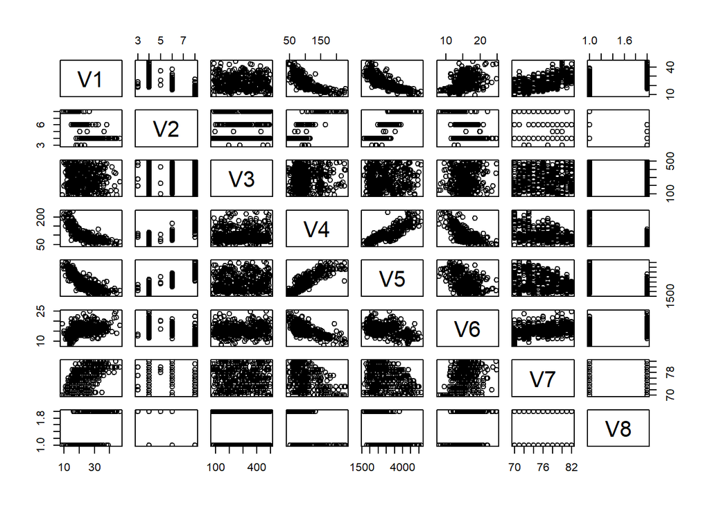

```r
numeric_dataset_1 = dataset_1[,-9]
pairs(numeric_dataset_1)
```

```r
cor(numeric_dataset_1)
```

```
##             V1          V2           V3          V4          V5          V6
## V1  1.00000000 -0.77761751 -0.044596928 -0.77842678 -0.83224421  0.42332854
## V2 -0.77761751  1.00000000  0.026197159  0.84298336  0.89752734 -0.50468338
## V3 -0.04459693  0.02619716  1.000000000  0.02273834  0.01919333  0.02368749
## V4 -0.77842678  0.84298336  0.022738341  1.00000000  0.86453774 -0.68919551
## V5 -0.83224421  0.89752734  0.019193330  0.86453774  1.00000000 -0.41683920
## V6  0.42332854 -0.50468338  0.023687489 -0.68919551 -0.41683920  1.00000000
## V7  0.58054097 -0.34564744 -0.003150699 -0.41636148 -0.30911988  0.29031611
## V8  0.56516059 -0.61049378 -0.001686569 -0.48962479 -0.60097827  0.25822413
##              V7           V8
## V1  0.580540966  0.565160593
## V2 -0.345647440 -0.610493780
## V3 -0.003150699 -0.001686569
## V4 -0.416361477 -0.489624788
## V5 -0.309119881 -0.600978271
## V6  0.290316113  0.258224128
## V7  1.000000000  0.136065489
## V8  0.136065489  1.000000000
```

Considerando la variable 4 como una variable dependiente, se puede considerar que tiene una relación clara con la variable 1, 5, 6, de tipo regresión. Por otra parte, se pueden observar claras distinciones divisiones en las variables 2 y 8. Finalmente, las variables 3 y 7 aparentan una ausencia de relación entre los datos.

## Inciso 2.

Utiliza el criterio de Akaike y la selección por pasos en dirección mixta de variables predictoras. Escriba la ecuación del modelo de regresión resultante.

```r
ols = lm(V4 ~ ., data = numeric_dataset_1)
both_ols_aic = step(ols, direction = "both", trace = 1)
```

```
## Start:  AIC=2014.17
## V4 ~ V1 + V2 + V3 + V5 + V6 + V7 + V8
##
##        Df Sum of Sq    RSS    AIC
## - V1    1        15  64143 2012.3
## - V3    1       154  64283 2013.1
## <none>               64129 2014.2
## - V2    1       687  64816 2016.3
## - V8    1      1003  65132 2018.3
## - V7    1      2227  66355 2025.5
## - V5    1     29778  93907 2161.7
## - V6    1     56292 120420 2259.2
##
## Step:  AIC=2012.26
## V4 ~ V2 + V3 + V5 + V6 + V7 + V8
##
##        Df Sum of Sq    RSS    AIC
## - V3    1       163  64306 2011.3
## <none>               64143 2012.3
## + V1    1        15  64129 2014.2
## - V2    1       681  64824 2014.4
## - V8    1      1004  65147 2016.3
## - V7    1      3998  68141 2034.0
## - V5    1     44573 108717 2217.1
## - V6    1     56566 120709 2258.1
##
## Step:  AIC=2011.26
## V4 ~ V2 + V5 + V6 + V7 + V8
##
##        Df Sum of Sq    RSS    AIC
## <none>               64306 2011.3
## + V3    1       163  64143 2012.3
## + V1    1        23  64283 2013.1
## - V2    1       706  65012 2013.5
## - V8    1      1020  65326 2015.4
## - V7    1      3995  68301 2032.9
## - V5    1     44520 108826 2215.5
## - V6    1     56409 120714 2256.1
```

Según el criterio de Akaike utilizando un paso en dirección de “ambos”, el mejor modelo para predicir la variable $V_4$ es:

```r
both_ols_aic$coefficients
```

```
##  (Intercept)           V2           V5           V6           V7           V8
## 152.70372284   1.94894336   0.02893708  -5.12413773  -0.93859096   4.28235975
```

La ecuación del mejor modelo que representa los datos es la siguiente:

$$\hat{V_4} = 1.949V_2 + 0.029 V_5 - 5.124V_6 - 0.939V_7 + 4.282V_8 +
152.704$$

## Inciso 3.

Analiza para el modelo obtenido: (Selecciona 2 criterios)

```r
best_ols = lm(V4 ~ V2 + V5 + V6 + V7 + V8, data = numeric_dataset_1)
summary(best_ols)
```

```
##
## Call:
## lm(formula = V4 ~ V2 + V5 + V6 + V7 + V8, data = numeric_dataset_1)
##
## Residuals:
##     Min      1Q  Median      3Q     Max
## -30.573  -7.858  -1.386   5.703  80.065
##
## Coefficients:
##              Estimate Std. Error t value Pr(>|t|)
## (Intercept) 152.70372   16.71345   9.137  < 2e-16 ***
## V2            1.94894    0.94641   2.059   0.0401 *
## V5            0.02894    0.00177  16.347  < 2e-16 ***
## V6           -5.12414    0.27847 -18.401  < 2e-16 ***
## V7           -0.93859    0.19166  -4.897 1.43e-06 ***
## V8            4.28236    1.73089   2.474   0.0138 *
## ---
## Signif. codes:  0 '***' 0.001 '**' 0.01 '*' 0.05 '.' 0.1 ' ' 1
##
## Residual standard error: 12.91 on 386 degrees of freedom
## Multiple R-squared:  0.889,  Adjusted R-squared:  0.8876
## F-statistic: 618.2 on 5 and 386 DF,  p-value: < 2.2e-16
```

- Porcentaje de variabilidad explicada por el modelo.

Observando en el resumen del mejor modelo, el modelo obtuvo una $R^2$ ajustada del $88.8\%$, indicando que el modelo puede explicar este porcentaje de la variabilidad de los datos.

- Significancia de cada uno de los coeficientes $\beta_i$.

Recordemos que $H_0 :=$ El coeficiente no es significativo ($\beta_i = 0$) y $H_A :=$ El coeficiente si es significativo ($\beta_i \neq 0$). Observamos que todos los coeficientes en el mejor modelo tienen un valor de $p < 0.05$, por lo que todos son estadísticamente significativos. Esto implica que se rechazan las hipótesis nulas, y se infiere que los términos y sus respectivos coeficientes son significativos al modelo y a los datos.

## Inciso 4.

Valida el modelo. Verifica si se satisfacen todos los supuestos del modelo: (Selecciona 2 supuestos)

### Normalidad de los residuos

Shapiro-Wilk normality test

- $H_0:=$ La distribución de los errores es normal
- $H_A:=$ La distribución de los errores no es normal

```r
shapiro.test(best_ols$residuals)
```

```
##
##  Shapiro-Wilk normality test
##
## data:  best_ols$residuals
## W = 0.922, p-value = 2.12e-13
```

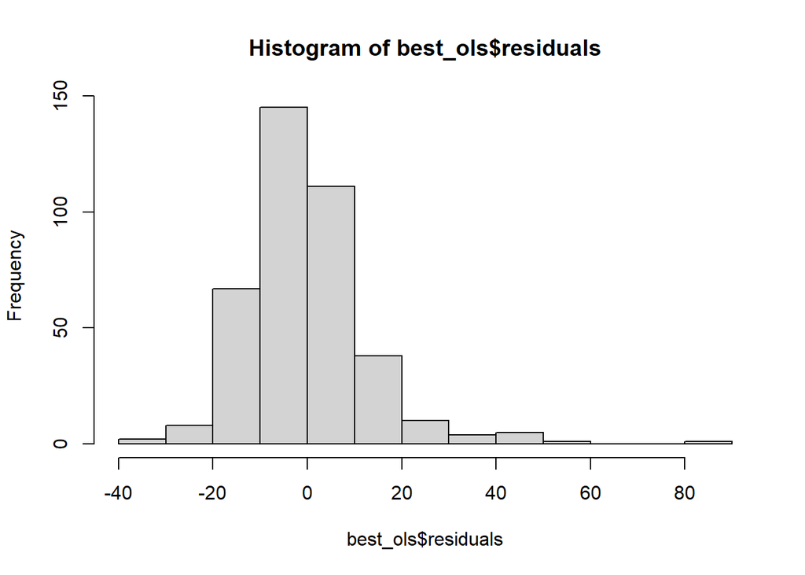

```r
hist(best_ols$residuals)
```

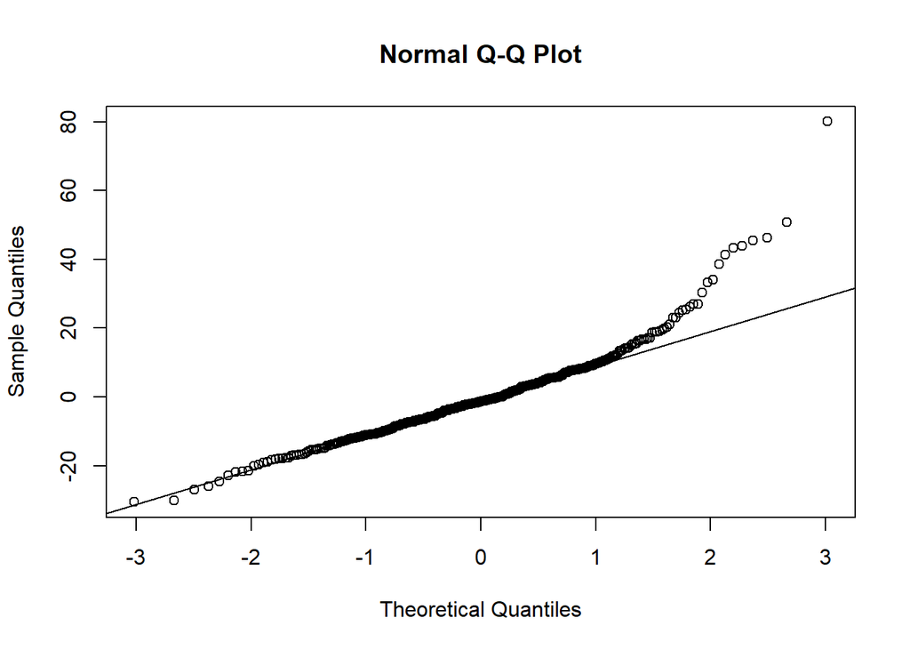

```r
qqnorm(best_ols$residuals)
qqline(best_ols$residuals)
```

El valor de $p$ de casi 0 indica que los errores no son parte de una distribución normal. Esto muy probablemente se debe al sesgo presente en los datos. Este supuesto se rechaza.

### Verificación de media cero

T Test

- $H_0:=$ La media de los errores es igual a 0.
- $H_A:=$ La media de los errores no es igual a 0.

```r
t.test(best_ols$residuals)
```

```
##
##  One Sample t-test
##
## data:  best_ols$residuals
## t = -3.204e-16, df = 391, p-value = 1
## alternative hypothesis: true mean is not equal to 0
## 95 percent confidence interval:
##  -1.273468  1.273468
## sample estimates:
##     mean of x
## -2.075296e-16
```

```r
mean(best_ols$residuals)
```

```
## [1] -2.075296e-16
```

La prueba de T sugiere que la media de los errores evidentemente es 0, por lo que este supuesto parece ser aprobado.

### Homocedasticidad

Breusch-Pagan

- $H_0:=$ Los datos tienen homocedasticidad.
- $H_A:=$ Los datos no tienen homocedasticidad.

```r
bptest(best_ols)
```

```
##
##  studentized Breusch-Pagan test
##
## data:  best_ols
## BP = 34.833, df = 5, p-value = 1.624e-06
```

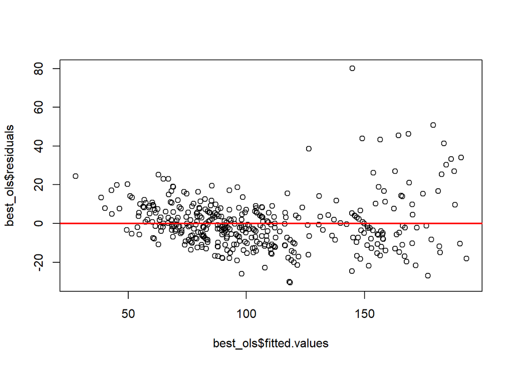

```r
plot(best_ols$fitted.values, best_ols$residuals)
abline(h=0, col = "red", lwd = 2)
```

### Independencia

Durbin Watson

- $H_0:=$ No existe autocorrelación en los datos
- $H_A:=$ Existe autocorrelacion en los datos.

```r
dwtest(best_ols)
```

```
##
##  Durbin-Watson test
##
## data:  best_ols
## DW = 1.4181, p-value = 1.721e-09
## alternative hypothesis: true autocorrelation is greater than 0
```

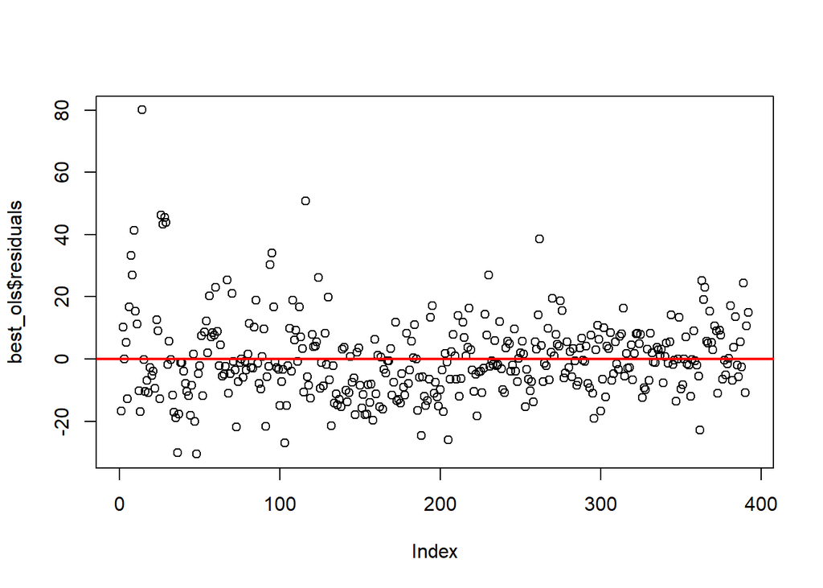

```r
plot(best_ols$residuals)
abline(h=0, col = "red", lwd = 2)
```

## Inciso 5.

Presenta el intervalo de confianza para la respuesta media y el intervalo de predicción para la última observación de la base de datos. ¿Qué significa cada uno de éstos intervalos?

```r
alfa = 0.05
# confint(best_ols, level = 1 - alfa)

pred_conf = predict(best_ols, interval = "confidence", level = 1 - alfa)
tail(data.frame(pred_conf), 1)
```

```
##          fit      lwr      upr
## 392 67.11797 63.64269 70.59325
```

```r
pred_pred = predict(best_ols, interval = "prediction", level = 1 - alfa)
tail(data.frame(pred_pred), 1)
```

```
##          fit      lwr      upr
## 392 67.11797 41.50393 92.73201
```

La matriz `pred_conf` contiene el intervalo de confianza de la predicción de los datos. Si bien cuando se ajusta un modelo lineal a datos, los coeficientes tienen sus intervalos de confianza. Por ende, por variaciones sobre cada uno de estos coeficientes, la prediccion puede variar. El intervalo presentado son los limites que esta predicción segun el modelo puede tener.

Por otra parte, `pred_pred` tiene los intervalos de confianza la variabilidad de los datos. Se puede interpretar como una franja de valores esperados que formen parte de la regresión. A diferencia de la matriz `pred_conf`, se hace énfasis en que este intervalo de confianza no es la certidumbre sobre la predicción, sino la certidumbre de que un dato pertenezca al modelo.

## Inciso 6.

¿Recomendarías algún modelo de regresión lineal (simple o múltiple) para predecir la variable V3 a partir de las otras variables dadas? Argumente su respuesta.

Definitivamente no sería ideal hacer un modelo sobre la variable $V_3$, ya que carece de alguna relación con el resto de las variables. Se puede observar tanto gráficamente como en la matriz de correlaciones en el inciso 1. Es decir, la variable V3 parece ser independiente del resto de las variables.

# Pregunta 2.

```r
dataset_2 = read.csv("data/Placement.csv")
head(dataset_2, 5)
```

```
##   sl_no gender ssc_p hsc_p degree_p  degree_t workex etest_p specialisation
## 1     1      M 67.00 91.00    58.00  Sci&Tech     No    55.0         Mkt&HR
## 2     2      M 79.33 78.33    77.48  Sci&Tech    Yes    86.5        Mkt&Fin
## 3     3      M 65.00 68.00    64.00 Comm&Mgmt     No    75.0        Mkt&Fin
## 4     4      M 56.00 52.00    52.00  Sci&Tech     No    66.0         Mkt&HR
## 5     5      M 85.80 73.60    73.30 Comm&Mgmt     No    96.8        Mkt&Fin
##   mba_p     status
## 1 58.80     Placed
## 2 66.28     Placed
## 3 57.80     Placed
## 4 59.43 Not Placed
## 5 55.50     Placed
```

## Inciso 1.

Divida el conjunto de datos en un conjunto de entrenamiento (80% de las observaciones y de prueba (20% de las observaciones) manteniendo similares proporciones de la variable en cada conjunto de datos y reporte:

```r
target = "status"
predictor = "degree_p"

filtered_dataset_2 = dataset_2[,c(predictor,target)]
filtered_dataset_2$status = as.factor(filtered_dataset_2$status)
train_index = sample(nrow(filtered_dataset_2), 0.8 * nrow(filtered_dataset_2))
train_dataset_2 = filtered_dataset_2[train_index,]
test_dataset_2 = filtered_dataset_2[-train_index,]
```

- Proporción de la clase negativa y positiva en el conjunto de entrenamiento:

```r
train_dataset_2 %>%
  group_by(status) %>%
  summarise(count = n())
```

```
## # A tibble: 2 × 2
##   status     count
##   <fct>      <int>
## 1 Not Placed    49
## 2 Placed       123
```

- Proporción de la clase negativa y positiva en el conjunto de prueba:

```r
test_dataset_2 %>%
  group_by(status) %>%
  summarise(count = n())
```

```
## # A tibble: 2 × 2
##   status     count
##   <fct>      <int>
## 1 Not Placed    18
## 2 Placed        25
```

## Inciso 2.

Formule el modelo de regresión logística simple correspondiente y escriba las ecuaciones para:

$$\log(\frac{P}{1-P}), P(Status =1)$$

```r
log_model = glm(status ~ degree_p, train_dataset_2, family='binomial', )

summary(log_model)
```

```
##
## Call:
## glm(formula = status ~ degree_p, family = "binomial", data = train_dataset_2)
##
## Coefficients:
##             Estimate Std. Error z value Pr(>|z|)
## (Intercept) -12.7025     2.3966  -5.300 1.16e-07 ***
## degree_p      0.2100     0.0375   5.602 2.12e-08 ***
## ---
## Signif. codes:  0 '***' 0.001 '**' 0.01 '*' 0.05 '.' 0.1 ' ' 1
##
## (Dispersion parameter for binomial family taken to be 1)
##
##     Null deviance: 205.54  on 171  degrees of freedom
## Residual deviance: 156.14  on 170  degrees of freedom
## AIC: 160.14
##
## Number of Fisher Scoring iterations: 5
```

```r
log_model$coefficients
```

```
## (Intercept)    degree_p
## -12.7024667   0.2100541
```

## Inciso 3.

Interprete en el contexto del problema:

- ¿Es estadísticamente significativa la variable predictora? Justifique.

```r
summary(log_model)
```

```
##
## Call:
## glm(formula = status ~ degree_p, family = "binomial", data = train_dataset_2)
##
## Coefficients:
##             Estimate Std. Error z value Pr(>|z|)
## (Intercept) -12.7025     2.3966  -5.300 1.16e-07 ***
## degree_p      0.2100     0.0375   5.602 2.12e-08 ***
## ---
## Signif. codes:  0 '***' 0.001 '**' 0.01 '*' 0.05 '.' 0.1 ' ' 1
##
## (Dispersion parameter for binomial family taken to be 1)
##
##     Null deviance: 205.54  on 171  degrees of freedom
## Residual deviance: 156.14  on 170  degrees of freedom
## AIC: 160.14
##
## Number of Fisher Scoring iterations: 5
```

```r
print("--------------------")
```

```
## [1] "--------------------"
```

```r
null_model = glm(status ~ 1, data = train_dataset_2, family = "binomial")
anova_resultado = anova(null_model, log_model, test = "Chi")
print(anova_resultado)
```

```
## Analysis of Deviance Table
##
## Model 1: status ~ 1
## Model 2: status ~ degree_p
##   Resid. Df Resid. Dev Df Deviance  Pr(>Chi)
## 1       171     205.54
## 2       170     156.14  1   49.403 2.084e-12 ***
## ---
## Signif. codes:  0 '***' 0.001 '**' 0.01 '*' 0.05 '.' 0.1 ' ' 1
```

La variable predictora ciertamente es significativa, debido a que su coeficiente tiene un valor de $p$ muy cercano al 0. Además, al comparar con un modelo nulo con una prueba ANOVA, se observa un valor de $p$ muy cercano a 0, por lo que implica que el modelo con esta variable predictora es mucho más significativo que un modelo nulo.

- Por por cada unidad que se incrementa el porcentaje de la nota de universidad ¿Cuánto se espera que cambie el logaritmo de *odds* de la variable status?

## Inciso 4.

Reporte únicamente las predicciones de probabilidades de las primeras 6 observaciones del conjunto de prueba.

```r
# Se voltea porque el modelo tomo los valores al reves
test_dataset_2$preds = 1 - predict(log_model, newdata = data.frame(degree_p = test_dataset_2$degree_p), type = "response")

head(test_dataset_2, 6)
```

```
##    degree_p     status      preds
## 7      79.0 Not Placed 0.02000022
## 8      66.0     Placed 0.23846644
## 11     60.0     Placed 0.52478445
## 17     65.6     Placed 0.25405824
## 18     64.0 Not Placed 0.32278608
## 19     64.0 Not Placed 0.32278608
```

## Inciso 5.

Encuentre el umbral óptimo de probabilidad para la clasificación de los datos y genere las predicciones de las clases a las que corresponden los datos. Reporte únicamente las predicciones de las clases de las primeras 6 observaciones del conjunto de prueba.

```r
test_dataset_2$preds_class = ifelse(test_dataset_2$preds > 0.5, 1, 0)

head(test_dataset_2, 6)
```

```
##    degree_p     status      preds preds_class
## 7      79.0 Not Placed 0.02000022           0
## 8      66.0     Placed 0.23846644           0
## 11     60.0     Placed 0.52478445           1
## 17     65.6     Placed 0.25405824           0
## 18     64.0 Not Placed 0.32278608           0
## 19     64.0 Not Placed 0.32278608           0
```

## Inciso 6.

Obtenga la matriz de confusión, identifique:

```r
tabla_contingencia = table(Real = test_dataset_2$status, Predicciones = test_dataset_2$preds_class)
print(tabla_contingencia)
```

```
##             Predicciones
## Real          0  1
##   Not Placed  9  9
##   Placed     20  5
```

1. El número de verdaderos positivos: 9
2. El número de falsos positivos: 5

## Inciso 7.

Concluya en el contexto del problema:

```r
tasa_error = sum(diag(tabla_contingencia)) / sum(tabla_contingencia)
sensibilidad = tabla_contingencia[2, 1] / sum(tabla_contingencia[2, ])
especificidad = tabla_contingencia[1, 2] / sum(tabla_contingencia[1, ])

cat("Tasa de Error:", tasa_error, "\n")
```

```
## Tasa de Error: 0.3255814
```

```r
cat("Sensibilidad:", sensibilidad, "\n")
```

```
## Sensibilidad: 0.8
```

```r
cat("Especificidad:", especificidad, "\n")
```

```
## Especificidad: 0.5
```

# Pregunta 3.

```r
dataset_3 = read.csv("data/mercurio.csv")
continuous_dataset_3 = dataset_3[,-c(1,2,12)]
head(dataset_3, 5)
```

```
##   X1           X2    X3  X4   X5    X6   X7 X8   X9  X10  X11 X12
## 1  1    Alligator   5.9 6.1  3.0   0.7 1.23  5 0.85 1.43 1.53   1
## 2  2        Annie   3.5 5.1  1.9   3.2 1.33  7 0.92 1.90 1.33   0
## 3  3       Apopka 116.0 9.1 44.1 128.3 0.04  6 0.04 0.06 0.04   0
## 4  4 Blue Cypress  39.4 6.9 16.4   3.5 0.44 12 0.13 0.84 0.44   0
## 5  5        Brick   2.5 4.6  2.9   1.8 1.20 12 0.69 1.50 1.33   1
```

```r
summary(dataset_3)
```

```
##        X1          X2                  X3               X4
##  Min.   : 1   Length:53          Min.   :  1.20   Min.   :3.600
##  1st Qu.:14   Class :character   1st Qu.:  6.60   1st Qu.:5.800
##  Median :27   Mode  :character   Median : 19.60   Median :6.800
##  Mean   :27                      Mean   : 37.53   Mean   :6.591
##  3rd Qu.:40                      3rd Qu.: 66.50   3rd Qu.:7.400
##  Max.   :53                      Max.   :128.00   Max.   :9.100
##        X5             X6               X7               X8
##  Min.   : 1.1   Min.   :  0.70   Min.   :0.0400   Min.   : 4.00
##  1st Qu.: 3.3   1st Qu.:  4.60   1st Qu.:0.2700   1st Qu.:10.00
##  Median :12.6   Median : 12.80   Median :0.4800   Median :12.00
##  Mean   :22.2   Mean   : 23.12   Mean   :0.5272   Mean   :13.06
##  3rd Qu.:35.6   3rd Qu.: 24.70   3rd Qu.:0.7700   3rd Qu.:12.00
##  Max.   :90.7   Max.   :152.40   Max.   :1.3300   Max.   :44.00
##        X9              X10              X11              X12
##  Min.   :0.0400   Min.   :0.0600   Min.   :0.0400   Min.   :0.0000
##  1st Qu.:0.0900   1st Qu.:0.4800   1st Qu.:0.2500   1st Qu.:1.0000
##  Median :0.2500   Median :0.8400   Median :0.4500   Median :1.0000
##  Mean   :0.2798   Mean   :0.8745   Mean   :0.5132   Mean   :0.8113
##  3rd Qu.:0.3300   3rd Qu.:1.3300   3rd Qu.:0.7000   3rd Qu.:1.0000
##  Max.   :0.9200   Max.   :2.0400   Max.   :1.5300   Max.   :1.0000
```

## Inciso 1.

Realice un análisis de normalidad de las variables continuas para identificar variables normales por pares y por distribución conjunta (se sugiere utilizar la prueba normalidad de Mardia y con prueba univariada de Anderson Darling). Identifique las variables que resultan Normales. Interprete su sesgo y curtosis.

```r
mvn_dataset_3 = mvn(data = continuous_dataset_3, mvnTest = "mardia", univariateTest = "AD")
mvn_dataset_3
```

```
## $multivariateNormality
##              Test        Statistic              p value Result
## 1 Mardia Skewness  434.33906591642 4.13584083502475e-26     NO
## 2 Mardia Kurtosis 5.76907272063334  7.9708906142173e-09     NO
## 3             MVN             <NA>                 <NA>     NO
##
## $univariateNormality
##               Test  Variable Statistic   p value Normality
## 1 Anderson-Darling    X3        3.6725  <0.001      NO
## 2 Anderson-Darling    X4        0.3496  0.4611      YES
## 3 Anderson-Darling    X5        4.0510  <0.001      NO
## 4 Anderson-Darling    X6        5.4286  <0.001      NO
## 5 Anderson-Darling    X7        0.9253  0.0174      NO
## 6 Anderson-Darling    X8        8.6943  <0.001      NO
## 7 Anderson-Darling    X9        1.9770  <0.001      NO
## 8 Anderson-Darling    X10       0.6585   0.081      YES
## 9 Anderson-Darling    X11       1.0469  0.0086      NO
##
## $Descriptives
##      n       Mean    Std.Dev Median  Min    Max  25th  75th       Skew
## X3  53 37.5301887 38.2035267  19.60 1.20 128.00  6.60 66.50  0.9679170
## X4  53  6.5905660  1.2884493   6.80 3.60   9.10  5.80  7.40 -0.2458771
## X5  53 22.2018868 24.9325744  12.60 1.10  90.70  3.30 35.60  1.3045868
## X6  53 23.1169811 30.8163214  12.80 0.70 152.40  4.60 24.70  2.4130571
## X7  53  0.5271698  0.3410356   0.48 0.04   1.33  0.27  0.77  0.5986343
## X8  53 13.0566038  8.5606773  12.00 4.00  44.00 10.00 12.00  2.5808773
## X9  53  0.2798113  0.2264058   0.25 0.04   0.92  0.09  0.33  1.0729099
## X10 53  0.8745283  0.5220469   0.84 0.06   2.04  0.48  1.33  0.4645925
## X11 53  0.5132075  0.3387294   0.45 0.04   1.53  0.25  0.70  0.9449951
##       Kurtosis
## X3  -0.4705349
## X4  -0.6239638
## X5   0.6130359
## X6   6.1042185
## X7  -0.6312607
## X8   6.0089455
## X9   0.4060828
## X10 -0.6692490
## X11  0.5733500
```

Las unicas variables que pasan las pruebas de Anderson-Darling para normalidad univariada son $X_4$ y $X_{10}$. En consecuencia, la distribución conjunta tiene valores $p$ muy cercanos a cero tanto para el sesgo como para la curtosis. Por ende, la distribución conjunta no es normal.

## Inciso 2.

Indique cuáles son las características de normalidad, sesgo y curtosis de las variables: X6 y X7

```r
mvn_dataset_3$Descriptives[c(4,5),]
```

```
##     n       Mean    Std.Dev Median  Min    Max 25th  75th      Skew   Kurtosis
## X6 53 23.1169811 30.8163214  12.80 0.70 152.40 4.60 24.70 2.4130571  6.1042185
## X7 53  0.5271698  0.3410356   0.48 0.04   1.33 0.27  0.77 0.5986343 -0.6312607
```

## Inciso 3.

Con las variables significativas identificadas en el inciso A, haz una prueba de normalidad multivariada, ¿resulta significativa esta distribución? Describe lejanías ligeras o importantes de sesgo y curtosis.

```r
best_mvn = mvn(data = dataset_3[,c("X4", "X10")], mvnTest = "mardia", univariateTest = "AD")
best_mvn
```

```
## $multivariateNormality
##              Test          Statistic           p value Result
## 1 Mardia Skewness   6.53855430534145 0.162377302354508    YES
## 2 Mardia Kurtosis -0.889321233851276 0.373830462900113    YES
## 3             MVN               <NA>              <NA>    YES
##
## $univariateNormality
##               Test  Variable Statistic   p value Normality
## 1 Anderson-Darling    X4        0.3496    0.4611    YES
## 2 Anderson-Darling    X10       0.6585    0.0810    YES
##
## $Descriptives
##      n      Mean   Std.Dev Median  Min  Max 25th 75th       Skew   Kurtosis
## X4  53 6.5905660 1.2884493   6.80 3.60 9.10 5.80 7.40 -0.2458771 -0.6239638
## X10 53 0.8745283 0.5220469   0.84 0.06 2.04 0.48 1.33  0.4645925 -0.6692490
```

Esta distribución es significativa, debido a que la distribución conjunta se aprueba. Las respectivas métricas de sesgo y curtosis para las distribuciones univariadas no afectan significativamente la distribucion conjunta.

## Inciso 4.

Elabora las gráficas de contorno de la distribución identificada en el inciso C. Interprétalas.

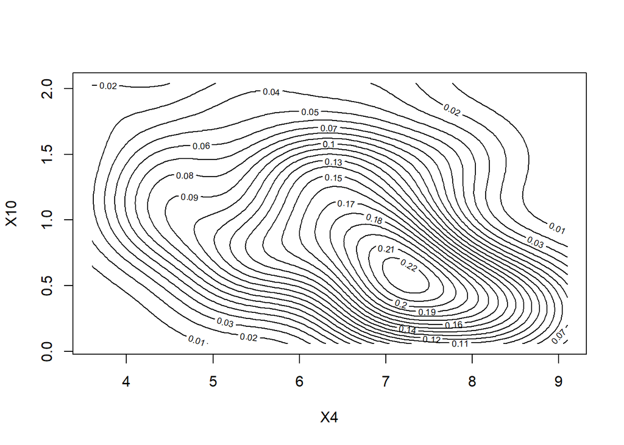

```
## $multivariateNormality
##              Test          Statistic           p value Result
## 1 Mardia Skewness   6.53855430534145 0.162377302354508    YES
## 2 Mardia Kurtosis -0.889321233851276 0.373830462900113    YES
## 3             MVN               <NA>              <NA>    YES
##
## $univariateNormality
##               Test  Variable Statistic   p value Normality
## 1 Anderson-Darling    X4        0.3496    0.4611    YES
## 2 Anderson-Darling    X10       0.6585    0.0810    YES
##
## $Descriptives
##      n      Mean   Std.Dev Median  Min  Max 25th 75th       Skew   Kurtosis
## X4  53 6.5905660 1.2884493   6.80 3.60 9.10 5.80 7.40 -0.2458771 -0.6239638
## X10 53 0.8745283 0.5220469   0.84 0.06 2.04 0.48 1.33  0.4645925 -0.6692490
```

```r
mvn(data = dataset_3[,c("X4", "X10")], mvnTest = "mardia", univariateTest = "AD", multivariatePlot = "contour")
```

Se puede identificar claramente la media y sus respectivos valores de nivel, con los que se pueden encontrar la proporción de los datos que caen bajo ese contorno.

## Inciso 5.

Con el vector de medias y la matriz de covarianza de la normal multivariada encontrada en el inciso C, obtén la probabilidad acumulada para los valores de la observación 26 (en tu matriz de datos encuentra los valores de las variables que intervienen en tu modelo C y utilizalos para calcular esa probabilidad. La matriz de varianza covarianza y el vector de medias obtenlo de tus datos).

```r
as.vector(dataset_3[26,c("X4", "X10")])
```

```
## $X4
## [1] 6.9
##
## $X10
## [1] 1.12
```

```r
mu = colMeans(dataset_3[,c("X4", "X10")])
sigma = cov(dataset_3[,c("X4", "X10")])
bound = c(6.9, 1.12)

# Calcular la probabilidad utilizando la distribución normal multivariada
p_value = pmnorm(x = bound, mean = mu, varcov = sigma)
p_value
```

```
## [1] 0.3285405
```

La probabilidad acumulada sería de 0.329.

## Incisos 6.

Con el total de datos calcula la distancia de Mahalanobis de cada observación al centroide (vector de medias) con respecto a la matriz de covarianzas. ¿Qué observación está más alejada, según la distancia de Mahalanobis, del centroide? ¿Qué observación está más cercana?

```r
mu = colMeans(continuous_dataset_3)
sigma = cov(continuous_dataset_3)
mahalanobis_dist = mahalanobis(x = continuous_dataset_3, center = mu, cov = sigma)

# Identificar la observación más alejada y la más cercana al centroide
max_distance_index = which.max(mahalanobis_dist)
min_distance_index = which.min(mahalanobis_dist)

max_distance_index
```

```
## [1] 24
```

```r
min_distance_index
```

```
## [1] 51
```

# Problema 4.

```r
dataset_4 = read.csv("data/recordswomen.csv")
numeric_dataset_4 = dataset_4[,-1]
head(dataset_4, 5)
```

```
##   COUNTRY    X1    X2    X3   X4   X5   X6     X7
## 1     ARG 11.57 22.94 52.50 2.05 4.25 9.19 150.32
## 2     AUS 11.12 22.23 48.63 1.98 4.02 8.63 143.51
## 3     AUT 11.15 22.70 50.62 1.94 4.05 8.78 154.35
## 4     BEL 11.14 22.48 51.45 1.97 4.08 8.82 143.05
## 5     BER 11.46 23.05 53.30 2.07 4.29 9.81 174.18
```

## Inciso 1.

Con base en al menos tres criterios (por ejemplo, porcentaje de variación acumulada, gráfica de Scree y los valores de las cargas ) determinar cuántos componentes son suficientes para explicar razonablemente la mayoría de la variación.

```r
# Análisis de componentes principales
pca = prcomp(numeric_dataset_4, scale. = TRUE)

# Porcentaje de variación acumulada
summary(pca)
```

```
## Importance of components:
##                           PC1     PC2    PC3     PC4    PC5     PC6     PC7
## Standard deviation     2.4099 0.79290 0.5285 0.35292 0.3016 0.23349 0.11959
## Proportion of Variance 0.8297 0.08981 0.0399 0.01779 0.0130 0.00779 0.00204
## Cumulative Proportion  0.8297 0.91947 0.9594 0.97717 0.9902 0.99796 1.00000
```

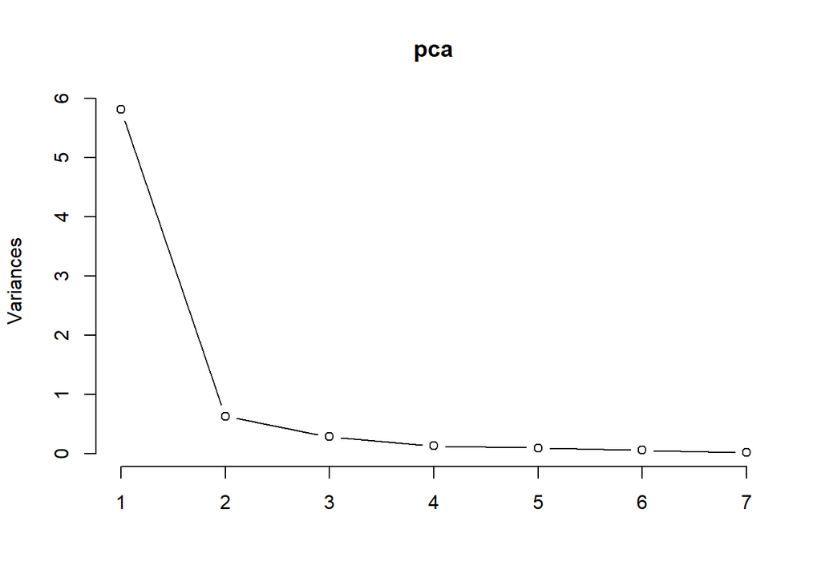

```r
# Gráfica Scree
screeplot(pca, type = "lines")
```

```r
# Valores de las cargas
pca$rotation
```

```
##           PC1        PC2        PC3         PC4         PC5         PC6
## X1 -0.3777657  0.4071756  0.1405803 -0.58706293  0.16706891  0.53969730
## X2 -0.3832103  0.4136291  0.1007833 -0.19407501 -0.09350016 -0.74493139
## X3 -0.3680361  0.4593531 -0.2370255  0.64543118 -0.32727328  0.24009405
## X4 -0.3947810 -0.1612459 -0.1475424  0.29520804  0.81905467 -0.01650651
## X5 -0.3892610 -0.3090877  0.4219855  0.06669044 -0.02613100 -0.18898771
## X6 -0.3760945 -0.4231899  0.4060627  0.08015699 -0.35169796  0.24049968
## X7 -0.3552031 -0.3892153 -0.7410610 -0.32107640 -0.24700821 -0.04826992
##            PC7
## X1  0.08893934
## X2 -0.26565662
## X3  0.12660435
## X4 -0.19521315
## X5  0.73076817
## X6 -0.57150644
## X7  0.08208401
```

Con la gráfica de Scree, se observa que con dos componentes principales es suficiente. La proporción acumulada de varianza sugiere que sea entre 2 y 3 componentes principales, pero para la poca ganancia que se tiene y por simplicidad para la reducción de dimensionalidad, 2 componentes principales es suficiente. Se observa para las cargas que despues del segundo componente principal, el poca la aportación de las variables para explicar esa variación. Por lo tanto, se refuerza la idea de considerar unicamente 2.

## Inciso 2.

Escribir las combinaciones lineales de los Componentes principales en función de las variables y cargas obtenidas de los componentes principales resultantes.

```r
pca$rotation[,c(1,2)]
```

```
##           PC1        PC2
## X1 -0.3777657  0.4071756
## X2 -0.3832103  0.4136291
## X3 -0.3680361  0.4593531
## X4 -0.3947810 -0.1612459
## X5 -0.3892610 -0.3090877
## X6 -0.3760945 -0.4231899
## X7 -0.3552031 -0.3892153
```

## Inciso 3.

Utilizando los dos primeros componentes hacer una gráfica de dispersión de las puntuaciones. Comentar el gráfico en función de la variabilidad.

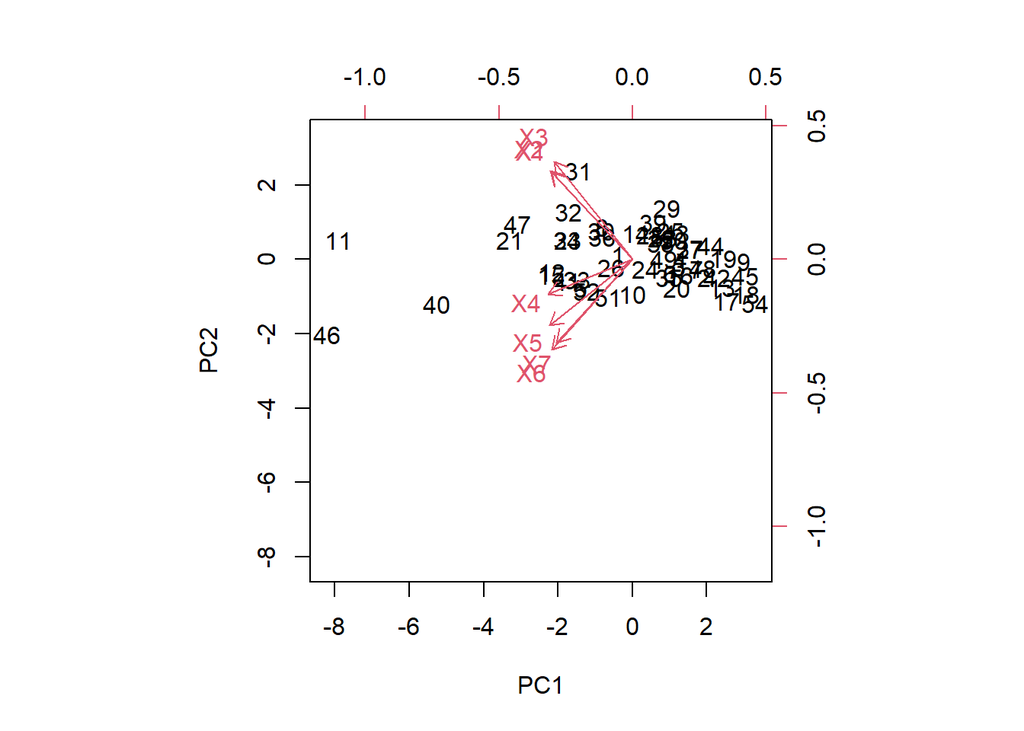

```r
biplot(pca, scale = 0)
```

Podemos observar mucho mayor variabilidad en el componente principal 1, y no tanta variabilidad en el segundo componente. Esto se refleja en las respectivas magnitudes de desviaciones estandar de cada componente.

## Inciso 4.

Hacer un gráfico vectorial de las variables e interpretar sus relaciones.

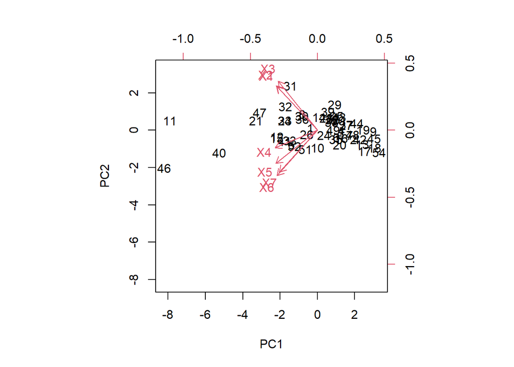

```r
biplot(pca, scale = 0)
```

Podemos observar como las variables se dividen principalmente en dos agrupaciones y direcciones, lo cual se refleja en el numero de componentes principales. Bien si dos dos direcciones distintas, ambas agrupaciones se relacionan en cuanto a su dirección (hacia los negativos del componente principal 1).

## Inciso 5.

Interprete los resultados de su análisis.

# Problema 5.

```r
dataset_5 = read.csv("data/recordswomen.csv")
numeric_dataset_5 = dataset_5[,-1]
head(dataset_5, 5)
```

```
##   COUNTRY    X1    X2    X3   X4   X5   X6     X7
## 1     ARG 11.57 22.94 52.50 2.05 4.25 9.19 150.32
## 2     AUS 11.12 22.23 48.63 1.98 4.02 8.63 143.51
## 3     AUT 11.15 22.70 50.62 1.94 4.05 8.78 154.35
## 4     BEL 11.14 22.48 51.45 1.97 4.08 8.82 143.05
## 5     BER 11.46 23.05 53.30 2.07 4.29 9.81 174.18
```

## Inciso 1.

Justifique por qué es adecuado el uso del Análisis factorial (hacer la prueba de esfericidad de Bartlett y KMO).

```r
# Matriz de correlación
corr.test(numeric_dataset_5)
```

```
## Call:corr.test(x = numeric_dataset_5)
## Correlation matrix
##      X1   X2   X3   X4   X5   X6   X7
## X1 1.00 0.94 0.87 0.81 0.78 0.73 0.67
## X2 0.94 1.00 0.91 0.82 0.80 0.73 0.68
## X3 0.87 0.91 1.00 0.81 0.72 0.67 0.68
## X4 0.81 0.82 0.81 1.00 0.91 0.87 0.85
## X5 0.78 0.80 0.72 0.91 1.00 0.97 0.79
## X6 0.73 0.73 0.67 0.87 0.97 1.00 0.80
## X7 0.67 0.68 0.68 0.85 0.79 0.80 1.00
## Sample Size
## [1] 54
## Probability values (Entries above the diagonal are adjusted for multiple tests.)
##    X1 X2 X3 X4 X5 X6 X7
## X1  0  0  0  0  0  0  0
## X2  0  0  0  0  0  0  0
## X3  0  0  0  0  0  0  0
## X4  0  0  0  0  0  0  0
## X5  0  0  0  0  0  0  0
## X6  0  0  0  0  0  0  0
## X7  0  0  0  0  0  0  0
##
##  To see confidence intervals of the correlations, print with the short=FALSE option
```

```r
# Prueba de esfericidad de Bartlett
check_sphericity_bartlett(numeric_dataset_5)
```

```
## # Test of Sphericity
##
## Bartlett's test of sphericity suggests that there is sufficient significant correlation in the data for factor analysis (Chisq(21) = 578.92, p < .001).
```

```r
# Medida de adecuación muestral de Kaiser-Meyer-Olkin (KMO)
KMO(cor(numeric_dataset_5))
```

```
## Kaiser-Meyer-Olkin factor adequacy
## Call: KMO(r = cor(numeric_dataset_5))
## Overall MSA =  0.82
## MSA for each item =
##   X1   X2   X3   X4   X5   X6   X7
## 0.89 0.78 0.86 0.85 0.74 0.76 0.88
```

La prueba de esfericidad de Bartlett muestra una $p$ menor a $0.001$, indicando que la relación entre variables es lo suficientemente significativa para un análisis factorial. La prueba de KMO respalda estos resultados, teniendo un valor de 0.82 (con valor crítico de 0.5). Por ende, se pueden considerar aptos los datos para un análisis factorial.

## Inciso 2.

Justifique el número de factores principales que se utilizarán en el modelo. Escriba los factores de los que constará su modelo.

```r
pca = prcomp(numeric_dataset_5)
# Eigenvalores
pca$sdev
```

```
## [1] 16.56389683  2.00416620  0.51793567  0.33844677  0.12298092  0.05093724
## [7]  0.02483491
```

```r
# Aportacion acumulada
cumsum(pca$sdev) / sum(pca$sdev)
```

```
## [1] 0.8440977 0.9462302 0.9726242 0.9898715 0.9961386 0.9987344 1.0000000
```

```r
# Combinaciones Lineales
pca$rotation
```

```
##             PC1         PC2         PC3          PC4           PC5
## X1 -0.016123307  0.11485619  0.17348957 -0.292124494  9.325622e-01
## X2 -0.038657909  0.29039299  0.38670581 -0.794578949 -3.543286e-01
## X3 -0.107793074  0.93844399 -0.22555878  0.238107150 -1.355429e-03
## X4 -0.004504024  0.01340703  0.03608601  0.009212813  1.547251e-02
## X5 -0.013072642  0.03631915  0.26812163  0.068410358 -6.671958e-02
## X6 -0.039484872  0.07871002  0.83389231  0.470904246 -9.287424e-03
## X7 -0.992409201 -0.11878027 -0.03025618 -0.009843642 -2.323022e-05
##              PC6          PC7
## X1  0.0226814395 -0.030430700
## X2 -0.0832625101  0.028266709
## X3  0.0055727214 -0.009943020
## X4  0.3768162267  0.925301584
## X5  0.8833633010 -0.370349317
## X6 -0.2649535334  0.069511587
## X7 -0.0005351329 -0.001613339
```

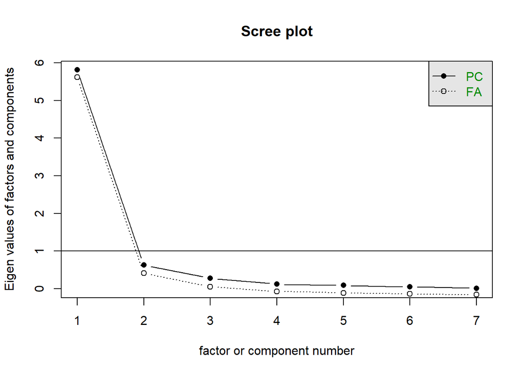

```r
cor_dataset = cor(numeric_dataset_5)
scree(numeric_dataset_5)
```

```r
pca$rotation[,c(1,2)]
```

```
##             PC1         PC2
## X1 -0.016123307  0.11485619
## X2 -0.038657909  0.29039299
## X3 -0.107793074  0.93844399
## X4 -0.004504024  0.01340703
## X5 -0.013072642  0.03631915
## X6 -0.039484872  0.07871002
## X7 -0.992409201 -0.11878027
```

## Inciso 3.

Identifique las comunalidades de los factores del modelo propuesto, y los errores: interprete si se necesita un nuevo factor.

```r
fm_mode = "minres"

fa_none = fa(cor_dataset, nfactors = 2, rotate = "none", fm = fm_mode)
fa_varimax = fa(cor_dataset, nfactors = 2, rotate = "varimax", fm = fm_mode)
fa_oblimin = fa(cor_dataset, nfactors = 2, rotate = "oblimin", fm = fm_mode)

fa_none
```

```
## Factor Analysis using method =  minres
## Call: fa(r = cor_dataset, nfactors = 2, rotate = "none", fm = fm_mode)
## Standardized loadings (pattern matrix) based upon correlation matrix
##     MR1   MR2   h2    u2 com
## X1 0.90  0.29 0.90 0.104 1.2
## X2 0.93  0.33 0.97 0.031 1.2
## X3 0.87  0.31 0.86 0.143 1.2
## X4 0.94 -0.12 0.90 0.095 1.0
## X5 0.94 -0.27 0.95 0.047 1.2
## X6 0.91 -0.35 0.94 0.058 1.3
## X7 0.82 -0.19 0.71 0.291 1.1
##
##                        MR1  MR2
## SS loadings           5.70 0.53
## Proportion Var        0.81 0.08
## Cumulative Var        0.81 0.89
## Proportion Explained  0.92 0.08
## Cumulative Proportion 0.92 1.00
##
## Mean item complexity =  1.2
## Test of the hypothesis that 2 factors are sufficient.
##
## df null model =  21  with the objective function =  11.62
## df of  the model are 8  and the objective function was  1
##
## The root mean square of the residuals (RMSR) is  0.02
## The df corrected root mean square of the residuals is  0.03
##
## Fit based upon off diagonal values = 1
## Measures of factor score adequacy
##                                                    MR1  MR2
## Correlation of (regression) scores with factors   0.99 0.95
## Multiple R square of scores with factors          0.99 0.91
## Minimum correlation of possible factor scores     0.98 0.82
```

```r
data.frame(NONE = fa_none$communalities, VARIMAX = fa_varimax$communalities, OBLIMIN = fa_oblimin$communalities)
```

```
##         NONE   VARIMAX   OBLIMIN
## X1 0.8959194 0.8959194 0.8959194
## X2 0.9688865 0.9688865 0.9688865
## X3 0.8574342 0.8574342 0.8574342
## X4 0.9048613 0.9048613 0.9048613
## X5 0.9527739 0.9527739 0.9527739
## X6 0.9420876 0.9420876 0.9420876
## X7 0.7091773 0.7091773 0.7091773
```

```r
cbind(fa_none$residual, fa_varimax$residual, fa_oblimin$residual)
```

```
##              X1           X2           X3           X4           X5
## X1  0.104106048  0.010031827 -0.005165155 -0.009375877  0.009731661
## X2  0.010031827  0.031137830 -0.002617611 -0.016775650  0.018278366
## X3 -0.005165155 -0.002617611  0.142597207  0.017753141 -0.018194555
## X4 -0.009375877 -0.016775650  0.017753141  0.095128822 -0.012712632
## X5  0.009731661  0.018278366 -0.018194555 -0.012712632  0.047221158
## X6  0.010150438  0.007483793 -0.009156771 -0.029252280  0.029985450
## X7 -0.017425046 -0.018159531  0.019114912  0.057232078 -0.030465351
##              X6          X7           X1           X2           X3           X4
## X1  0.010150438 -0.01742505  0.104106048  0.010031827 -0.005165155 -0.009375877
## X2  0.007483793 -0.01815953  0.010031827  0.031137830 -0.002617611 -0.016775650
## X3 -0.009156771  0.01911491 -0.005165155 -0.002617611  0.142597207  0.017753141
## X4 -0.029252280  0.05723208 -0.009375877 -0.016775650  0.017753141  0.095128822
## X5  0.029985450 -0.03046535  0.009731661  0.018278366 -0.018194555 -0.012712632
## X6  0.057912034 -0.01054701  0.010150438  0.007483793 -0.009156771 -0.029252280
## X7 -0.010547006  0.29083891 -0.017425046 -0.018159531  0.019114912  0.057232078
##              X5           X6          X7           X1           X2           X3
## X1  0.009731661  0.010150438 -0.01742505  0.104106048  0.010031827 -0.005165155
## X2  0.018278366  0.007483793 -0.01815953  0.010031827  0.031137830 -0.002617611
## X3 -0.018194555 -0.009156771  0.01911491 -0.005165155 -0.002617611  0.142597207
## X4 -0.012712632 -0.029252280  0.05723208 -0.009375877 -0.016775650  0.017753141
## X5  0.047221158  0.029985450 -0.03046535  0.009731661  0.018278366 -0.018194555
## X6  0.029985450  0.057912034 -0.01054701  0.010150438  0.007483793 -0.009156771
## X7 -0.030465351 -0.010547006  0.29083891 -0.017425046 -0.018159531  0.019114912
##              X4           X5           X6          X7
## X1 -0.009375877  0.009731661  0.010150438 -0.01742505
## X2 -0.016775650  0.018278366  0.007483793 -0.01815953
## X3  0.017753141 -0.018194555 -0.009156771  0.01911491
## X4  0.095128822 -0.012712632 -0.029252280  0.05723208
## X5 -0.012712632  0.047221158  0.029985450 -0.03046535
## X6 -0.029252280  0.029985450  0.057912034 -0.01054701
## X7  0.057232078 -0.030465351 -0.010547006  0.29083891
```

## Inciso 4.

Encuentre con ayuda de un gráfico de variables qué conviene más sin rotación o con rotación varimax. (se puede ayudar con la función **`fa`** de la librería psych y el gráfico de la función **`fa.diagram`**)

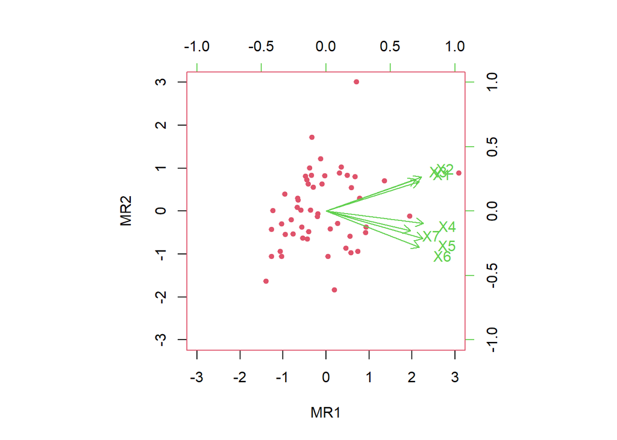

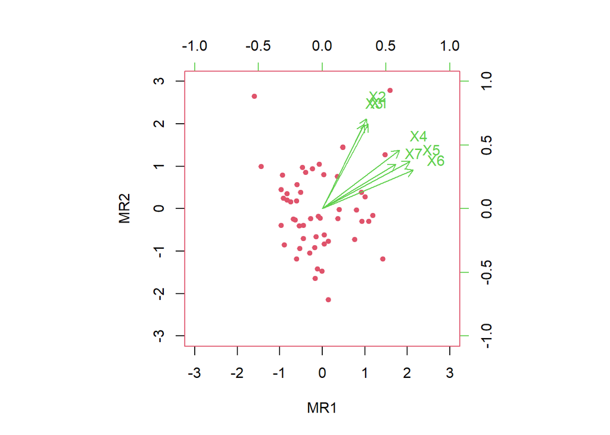

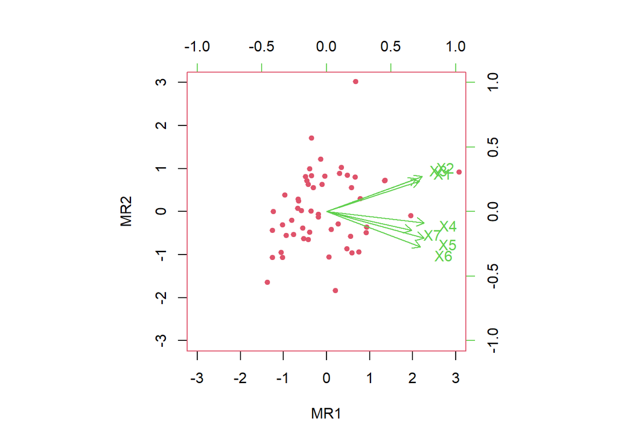

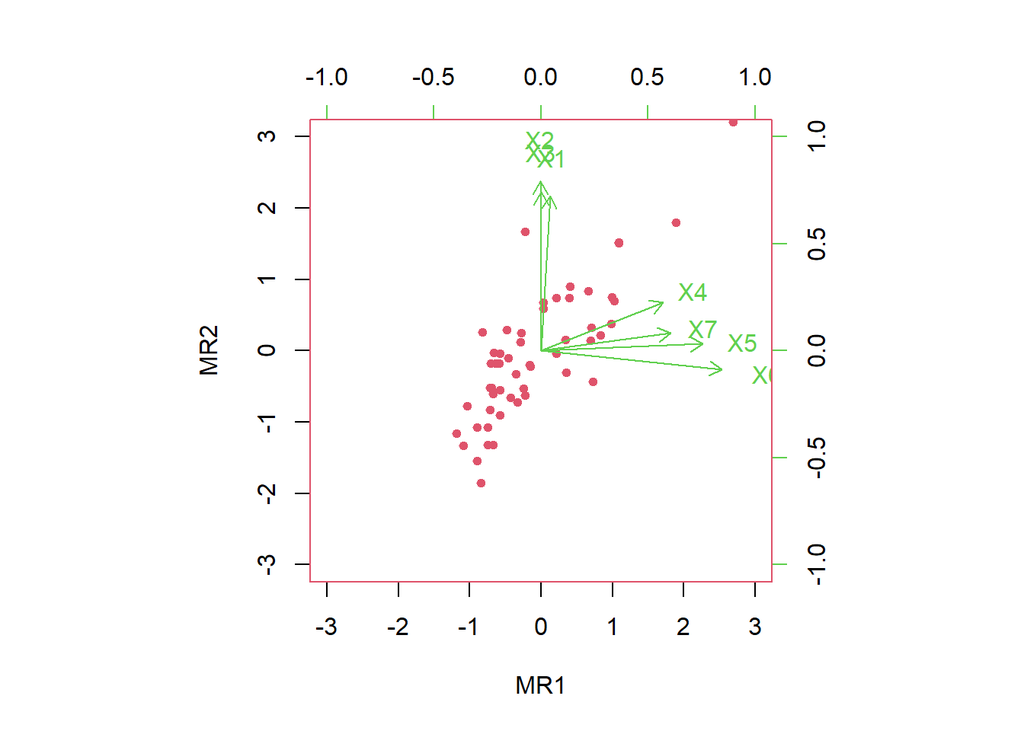

```r
rot = c("none", "varimax", "quartimax", "oblimin")
bi_mod = function(tipo){
biplot.psych(fa(numeric_dataset_5, nfactors = 2, fm=fm_mode, rotate = tipo), main = "",col=c(2,3,4),pch = c(21,18))  }
sapply(rot,bi_mod)
```

## Inciso 5.

Interprete los resultados de su análisis. Describa las variables latentes que encontró en el contexto del problema.

```r
fa_oblimin$loadings
```

```
##
## Loadings:
##    MR1    MR2
## X1         0.903
## X2         0.988
## X3         0.926
## X4  0.712  0.280
## X5  0.943
## X6  1.056 -0.110
## X7  0.757  0.103
##
##                  MR1   MR2
## SS loadings    3.088 2.751
## Proportion Var 0.441 0.393
## Cumulative Var 0.441 0.834
```

En el contexto del problema, se observa que el factor uno esta compuesto de las variables: X4, X5, X6 y X7. Por otro lado, el segundo factor está compuesto de X1, X2, X3 y con leves pesos en X4, X6 Y X7. El primer factor parece estar compuesto de variables de larga distancia, por lo que se infiere que puede ser un factor de “resistencia”. Por otro lado, las variables del factor 2 indican mayor influencia para las asociadas con carreras más rapidas, por lo que se puede inferir que el factor 2 puede hacer referencia a “velocidad”.

# Problema 6.

```r
dataset_6 = read.csv("data/humedal.csv")
head(dataset_6, 5)
```

```
##    humedal c_elec bicarb cloru sulfa calcio magn sodio pota    fosf
## 1     Caja  0.315 1.6694     5    86     55    4     4    2  1.8082
## 2  Camunas  8.000 3.7282  2388  7638   2123  972  1757    5  0.3228
## 3 Capacete  3.410 4.0642   732   881    218  122   379   41 74.5880
## 4   Cerero  3.940 1.4586  1359   772    251   96   710   14  0.0968
## 5    Chica  2.800 4.4862   220  2510    572   20   458    7  0.0968
```

## Inciso 1.

Realiza dos análisis clouster jerárquicos usando dos distintas distancias y métodos de aglomeración. Sigue los siguientes puntos para cada uno de ellos:

- Realiza el dendograma y selecciona el número de grupos óptimo (k). Ensaya diversos métodos de aglomeración hasta encontrar el óptimo. Reporta solo los dos que consideres que agruparon mejor a las variables.

[figure not shown]

```r
groups = 4

# Cálculo de la matriz de distancias
dist_euc <- dist(dataset_6[, -1], method = "euclidean")

jerarquico1 <- hclust(dist_euc, method = "average")

# Dendograma
plot(jerarquico1, main = "Dendograma (Distancia Euclidiana, Complete)")

# Seleccionar número óptimo de grupos y colorear el dendograma
rect.hclust(jerarquico1, k = groups, border = "red")
```

```r
# Asignación de grupos a cada observación
grupo1 <- cutree(jerarquico1, k = groups)

# Resultado: combinación de iris con el grupo asignado
resultado1 <- cbind(dataset_6, Grupo = grupo1)

resultado1
```

```
##      humedal c_elec bicarb cloru sulfa calcio magn sodio pota    fosf Grupo
## 1       Caja  0.315 1.6694     5    86     55    4     4    2  1.8082     1
## 2    Camunas  8.000 3.7282  2388  7638   2123  972  1757    5  0.3228     2
## 3   Capacete  3.410 4.0642   732   881    218  122   379   41 74.5880     1
## 4     Cerero  3.940 1.4586  1359   772    251   96   710   14  0.0968     1
## 5      Chica  2.800 4.4862   220  2510    572   20   458    7  0.0968     3
## 6      Dulce  1.560 2.4745   269   495    157   38   162    9  0.3228     1
## 7  FPSalinas 11.000 1.2206  3038   923    233  226  1488   11  0.0645     4
## 8  FPVicaria  8.750 2.6384  4325   456    234  229  2371   11  1.1947     4
## 9     Grande  2.600 3.3251   840  2270    609   86   284    7  0.5166     3
## 10   Gualdal  6.370 2.5483  2320  1040   1294  192   485   23  0.4843     1
## 11    Hoyos1  1.180 5.1966    13   499    202   20     5   18  6.7807     1
## 12     Lobon  0.570 1.7494   110    42     21   12    60    6  0.5812     1
## 13   Marcela  3.400 2.1189  1121   866    157  115   643    4  0.7426     1
## 14    Ratosa  3.480 1.7207  1484   554    151  151   708    7  0.1291     1
## 15   Redonda  4.620 1.0357   472  2964    752  160   652   34  0.1291     3
## 16    Salada  3.800 0.8685  1023  2274   1946  360   430   23  0.5489     3
## 17      Viso  0.300 1.8567     7    15     39    3     4    2  4.4882     1
```

```r
# Contar observaciones mal clasificadas
table(resultado1$humedal, resultado1$Grupo)
```

```
##
##             1 2 3 4
##   Caja      1 0 0 0
##   Camunas   0 1 0 0
##   Capacete  1 0 0 0
##   Cerero    1 0 0 0
##   Chica     0 0 1 0
##   Dulce     1 0 0 0
##   FPSalinas 0 0 0 1
##   FPVicaria 0 0 0 1
##   Grande    0 0 1 0
##   Gualdal   1 0 0 0
##   Hoyos1    1 0 0 0
##   Lobon     1 0 0 0
##   Marcela   1 0 0 0
##   Ratosa    1 0 0 0
##   Redonda   0 0 1 0
##   Salada    0 0 1 0
##   Viso      1 0 0 0
```

```r
# Calcular medias por grupo de clasificación
aggregate(. ~ Grupo, data = resultado1[, -1], FUN = mean)
```

```
##   Grupo c_elec   bicarb   cloru  sulfa  calcio  magn  sodio  pota    fosf
## 1     1 2.4525 2.485730  742.00  525.0  254.50  75.3  316.0 12.60 9.00219
## 2     2 8.0000 3.728200 2388.00 7638.0 2123.00 972.0 1757.0  5.00 0.32280
## 3     3 3.4550 2.428875  638.75 2504.5  969.75 156.5  456.0 17.75 0.32285
## 4     4 9.8750 1.929500 3681.50  689.5  233.50 227.5 1929.5 11.00 0.62960
```

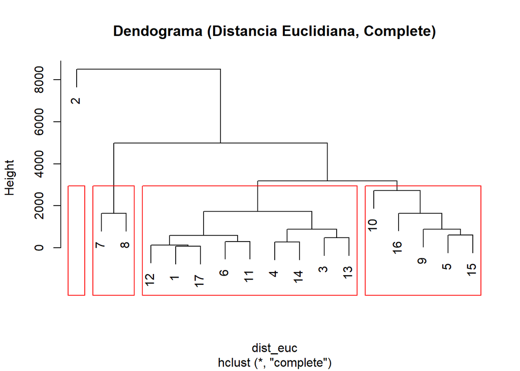

```r
groups = 4

# Cálculo de la matriz de distancias
dist_euc <- dist(dataset_6[, -1], method = "euclidean")

jerarquico1 <- hclust(dist_euc, method = "complete")

# Dendograma
plot(jerarquico1, main = "Dendograma (Distancia Euclidiana, Complete)")

# Seleccionar número óptimo de grupos y colorear el dendograma
rect.hclust(jerarquico1, k = groups, border = "red")
```

```r
# Asignación de grupos a cada observación
grupo1 <- cutree(jerarquico1, k = groups)

# Resultado: combinación de iris con el grupo asignado
resultado1 <- cbind(dataset_6, Grupo = grupo1)

resultado1
```

```
##      humedal c_elec bicarb cloru sulfa calcio magn sodio pota    fosf Grupo
## 1       Caja  0.315 1.6694     5    86     55    4     4    2  1.8082     1
## 2    Camunas  8.000 3.7282  2388  7638   2123  972  1757    5  0.3228     2
## 3   Capacete  3.410 4.0642   732   881    218  122   379   41 74.5880     1
## 4     Cerero  3.940 1.4586  1359   772    251   96   710   14  0.0968     1
## 5      Chica  2.800 4.4862   220  2510    572   20   458    7  0.0968     3
## 6      Dulce  1.560 2.4745   269   495    157   38   162    9  0.3228     1
## 7  FPSalinas 11.000 1.2206  3038   923    233  226  1488   11  0.0645     4
## 8  FPVicaria  8.750 2.6384  4325   456    234  229  2371   11  1.1947     4
## 9     Grande  2.600 3.3251   840  2270    609   86   284    7  0.5166     3
## 10   Gualdal  6.370 2.5483  2320  1040   1294  192   485   23  0.4843     3
## 11    Hoyos1  1.180 5.1966    13   499    202   20     5   18  6.7807     1
## 12     Lobon  0.570 1.7494   110    42     21   12    60    6  0.5812     1
## 13   Marcela  3.400 2.1189  1121   866    157  115   643    4  0.7426     1
## 14    Ratosa  3.480 1.7207  1484   554    151  151   708    7  0.1291     1
## 15   Redonda  4.620 1.0357   472  2964    752  160   652   34  0.1291     3
## 16    Salada  3.800 0.8685  1023  2274   1946  360   430   23  0.5489     3
## 17      Viso  0.300 1.8567     7    15     39    3     4    2  4.4882     1
```

```r
# Contar observaciones mal clasificadas
table(resultado1$humedal, resultado1$Grupo)
```

```
##
##             1 2 3 4
##   Caja      1 0 0 0
##   Camunas   0 1 0 0
##   Capacete  1 0 0 0
##   Cerero    1 0 0 0
##   Chica     0 0 1 0
##   Dulce     1 0 0 0
##   FPSalinas 0 0 0 1
##   FPVicaria 0 0 0 1
##   Grande    0 0 1 0
##   Gualdal   0 0 1 0
##   Hoyos1    1 0 0 0
##   Lobon     1 0 0 0
##   Marcela   1 0 0 0
##   Ratosa    1 0 0 0
##   Redonda   0 0 1 0
##   Salada    0 0 1 0
##   Viso      1 0 0 0
```

```r
# Calcular medias por grupo de clasificación
aggregate(. ~ Grupo, data = resultado1[, -1], FUN = mean)
```

```
##   Grupo   c_elec   bicarb     cloru     sulfa calcio      magn     sodio
## 1     1 2.017222 2.478778  566.6667  467.7778  139.0  62.33333  297.2222
## 2     2 8.000000 3.728200 2388.0000 7638.0000 2123.0 972.00000 1757.0000
## 3     3 4.038000 2.452760  975.0000 2211.6000 1034.6 163.60000  461.8000
## 4     4 9.875000 1.929500 3681.5000  689.5000  233.5 227.50000 1929.5000
##       pota     fosf
## 1 11.44444 9.948622
## 2  5.00000 0.322800
## 3 18.80000 0.355140
## 4 11.00000 0.629600
```

Ambos dendogramas parecen tener una mejor agrupación de “4”, bien si enrealidad el ideal sería 3. Ambos batallan con el registro numero 2, posiblemente al ser un dato atipico que al considerar con algoritmos de clustering lo separa como su propia agrupacion por su drástica diferencia. El segundo parece agrupar mejor, ya que las divisiones entre agrupaciones son más marcadas. Esto se debe a que el complete linkage divide segun la maxima distancia que se tenga entre grupos.

## Inciso 2.

Hacer el gráfico de agromeración no-jerárquica con el método de k-medias.

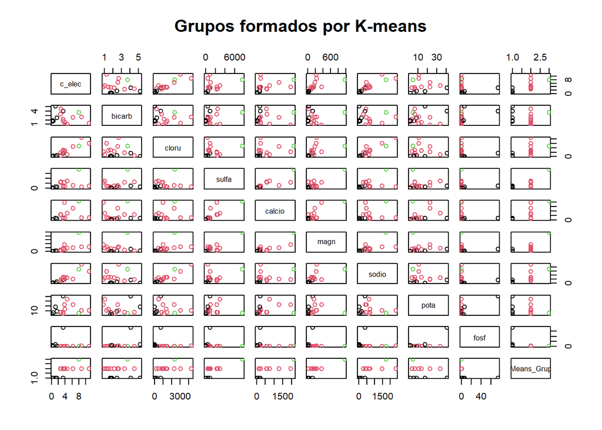

```r
# Análisis de K-means con k=3
kmeans_result <- kmeans(dataset_6[, -1], centers = 3)

# Asignar las observaciones a los grupos formados por K-means
dataset_6$KMeans_Grupo <- kmeans_result$cluster

# Gráfico de los grupos formados por K-means
pairs(dataset_6[, -1], col = kmeans_result$cluster, main = "Grupos formados por K-means")
```

```r
# Contar las observaciones mal clasificadas
table(dataset_6$humedal, dataset_6$KMeans_Grupo)
```

```
##
##             1 2 3
##   Caja      1 0 0
##   Camunas   0 0 1
##   Capacete  1 0 0
##   Cerero    0 1 0
##   Chica     0 1 0
##   Dulce     1 0 0
##   FPSalinas 0 1 0
##   FPVicaria 0 1 0
##   Grande    0 1 0
##   Gualdal   0 1 0
##   Hoyos1    1 0 0
##   Lobon     1 0 0
##   Marcela   0 1 0
##   Ratosa    0 1 0
##   Redonda   0 1 0
##   Salada    0 1 0
##   Viso      1 0 0
```

```r
aggregate(. ~ KMeans_Grupo, data = dataset_6[, -1], FUN = mean)
```

```
##   KMeans_Grupo c_elec   bicarb     cloru     sulfa    calcio      magn
## 1            1 1.2225 2.835133  189.3333  336.3333  115.3333  33.16667
## 2            2 5.0760 2.142100 1620.2000 1462.9000  619.9000 163.50000
## 3            3 8.0000 3.728200 2388.0000 7638.0000 2123.0000 972.00000
##       sodio pota     fosf
## 1  102.3333 13.0 14.76152
## 2  822.9000 14.1  0.40034
## 3 1757.0000  5.0  0.32280
```

Con este método es mucho más complicado obtener conglomeraciones signficativas. Observamos que no siempre es claro los criterios de divisiones para este algoritmo. Parece ser que al utilizar 3 centros, se puede observar mejor los distintos grupos al verlo como proyecciones entre variables.

## Inciso 3.

¿Cuál de los los métodos que ensayaste resultó mejor para clasificar las características de los humedales? ¿Es posible identificar las características que los agrupan?

El primer método muestra mejores resultados, especialmente al utilizar la jerarquía se puede hacer mayor distinción entre registros y clasificarlos mejor entre categorías. Si bien es posible llegar a conclusiones detrás de las agrupaciones, es complicado debido al registro influyente.